# CO2 Assignment

Raymond Infante

2023-04-09

Zeebe and Wolf-Gladrow, 2001

# 1. Introduction

### 1.1 Ocean Acidification

Since the Industrial Revolution carbon dioxide concentrations in the atmosphere had increased due to burning fossil fuels and changes in land uses. According to [NASA](https://climate.nasa.gov/news/2915/the-atmosphere-getting-a-handle-on-carbon-dioxide/#:~:text=The%20concentration%20of%20carbon%20dioxide,it%20was%20near%20370%20ppm.) the concentration of CO2 is nearly 412ppm representing a 47% increase since the beginning of the industrial age. “Being one of the most important green house gases after water vapor” (Zeebe and Wolf-Gladrow, 2001). This increase in atmospheric concentration can translate to an increase in the concentration of CO2 in the oceans. According to [NOAA](https://oceanservice.noaa.gov/facts/acidification.html#:~:text=Ocean%20acidification%20refers%20to%20a,CO2) the ocean can absorb approximately 30% of the CO2 in the atmosphere.

When CO2 enters the ocean surface it reacts with water forming carbonic acid. Rapidly dropping a hydrogen ion, resulting in bicarbonate ion. This bicarbonate ion can further react with water dissociating as hydrogen ion and carbonate ion. This present a problem, as seen in figure 1, there should exist an equilibrium of this elements in the ocean, but that’s not the case. While humans increase CO2 concentration in the atmosphere, more will be entering the oceans diverting the equilibrium in figure 1 to the left, lowering at the same time the pH in the ocean.

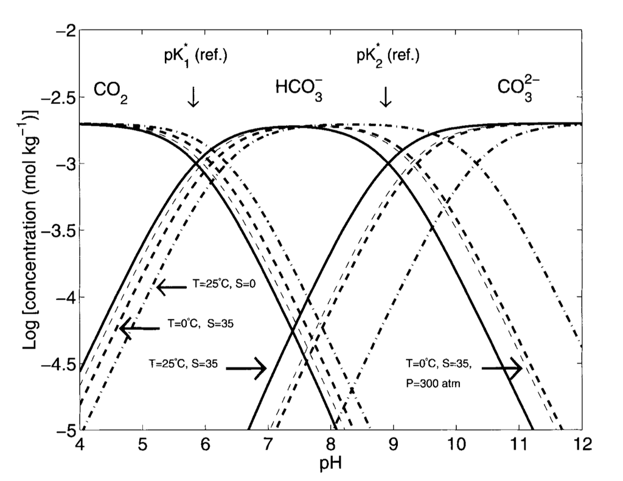

Fig. 1. CO2 Reactions, retreived from: Zeebe and Wolf-Gladrow, 2001. This figure chose the reactions and equilibrium points od the CO2 reactions.

The decrease in pH in the ocean is defined as Ocean Acidification. According to [NOAA](https://www.noaa.gov/education/resource-collections/ocean-coasts/ocean-acidification), Ocean Acidification had been affecting the marine ecosystem. Specially organism that produce hard skeleton and shells. This shells are product of carbonate. As seen in figure 1, carbonate ions are on the far right side of the equilibrium chart. If the equilibrium is displaces to the left, pH will be lower, the Hydrogen ions produced in this CO2 reactions will react with the carbonate and this organism will lack of it, increasing the possibility of not surviving.

Although most affected are the organism that uses carbonate ions, evidence according to [NOAA](https://www.noaa.gov/education/resource-collections/ocean-coasts/ocean-acidification) have shown that fishes, such as clown-fish, decrease the detection of predator in more acidic waters. The Ocean Acidification is affecting every where and every one, that’s why is important and imperative to study, understand, monitor and work with it.

In this assignment, our objectives is to quantify ocean acidification in the subtropical Nort Atlantic Ocean, and demonstrate the rates in which pCO2, pH and Aragonite are increasing or decreasing.

### 1.2 BATS

The Bermuda Atlantic Time-Series study [BATS](https://bats.bios.edu/) is one of the worlds longest oceanographic data acquisition runned by the Bermuda Institute of Ocean Science. In this study we are using BATS bottle data to study Ocean Acidiciation, specifically answering the question if pCO2 is increasing, pH is decreasing and the saturation state of Aragonite is decreasing in the surface water.

BATS is located 631 miles, or 1,016Km northeast of the United State as seen in Figure 2.  
The data obtained in this work is located approximately 170km southeast of Bermuda as seen in figure 3. Data was obtained from 1991 - 2021.

[figure not shown]

[figure not shown]

# 2. Methods

### 2.1 BATS

The data obtain from BATS is open source and can be downloaded [here](https://bats.bios.edu/bats-data/). This data was obtained every year since 1991, approximately 170km southeast of Bermuda. Several ships were used all this years: R/V Weatherbird I (cruises: 1,2,8,9,10,11, and 13), R/V Cape Henlopen (cruises: 3,4,5,6 and 7), R/V Cape Hatteras (cruises: 33,52,52a,53,53a,54,55,55a and 56), R/V Weatherbird II (cruises: 57-207), R/V Atlantic Explorer (cruises: 210-241 [242 was done by R/V Oceanus], 243-330), and R/V Endeavor (cruise 331) deploying Niskin bottles and CTD.

### 2.2 SeaCarb package

Seacarb package (v3.3.1) was used in this study, specially the “carb” function. Using R programming language (R version 4.2.2). This function returns parameter of seawater carbonate system such as: pH, pCO2, pCO2insitu, CO3 concentrations, DIC, Alkalinity and the saturation state of Aragonite and calcite.

The data of BATS bottles were wrangled, to obtain the necessary parameter for the “carb” function arguments specially the pCO2, pH and Saturation State of Aragonite. Then Plots and a linear models were used to obtain the increase or decrease rate of the parameters.

# 3. Results

### 3.1 pCO2 Increase

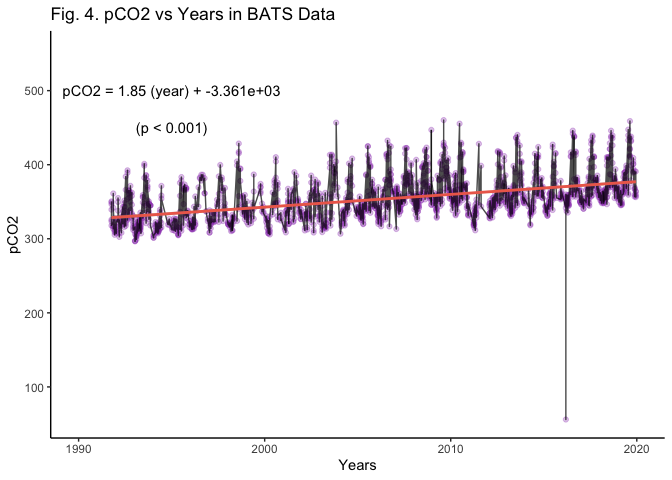

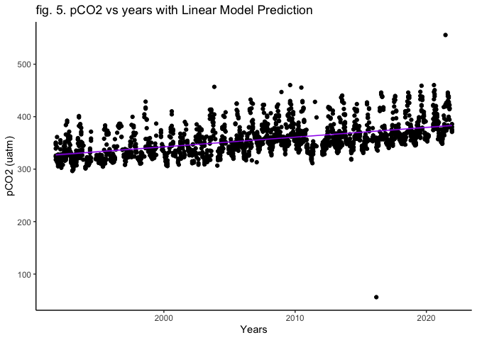

According to the data, there seems to exist a seasonal cycle of pCO2 concentrations. Higher concentrations were reccorded in summer and lower concentration on winter. Although, is evident that by plotting the entire time series of BATS and fitting a linear model (orange line), as seen in figure 4, there is a detectable (p<0.001) annual increase by 1.85±0.07 uatm/year. This can also be confirmed with figure 5, showing a prediction model (purple line) of increase pCO2 over the years. Finally, there is an odd point showing a concentration less than 100, is left in the data prior to confirm if it was an instrument/human error.

### 3.2 pH Decreasing

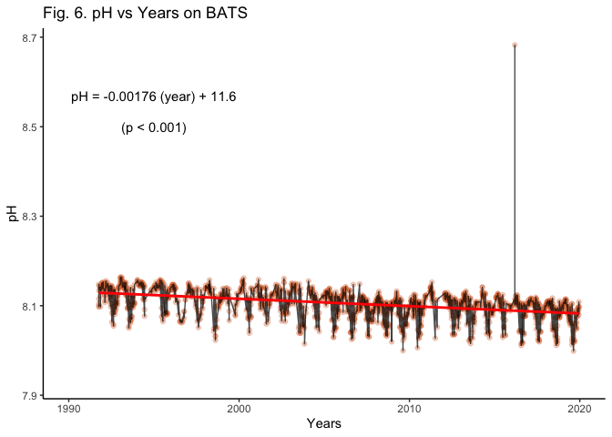

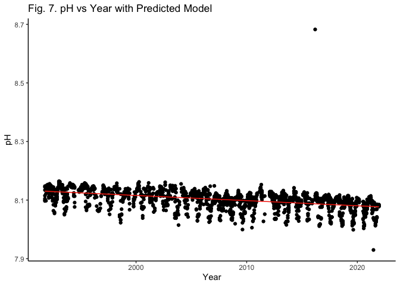

As similar to pCO2, there seems to be a seasonal cycle for pH, but inverse. Lower peeks of pH were detected on summer and higher peeks on winter. According to figure 6, by plotting the BATS time series and fitting a linear model (red line), shows that there’s a detectable (p<0.001) pH decrease of 0.00176±0.00000797 per year. This is also confirmed with figure 7, that shows the prediction model of pH (red line) decreasing. Finally, this plots also shows the odd data point, this point is not removed until confirmed that is an instrument or human error.

### 3.3 Saturation State of Aragonite Decreasing

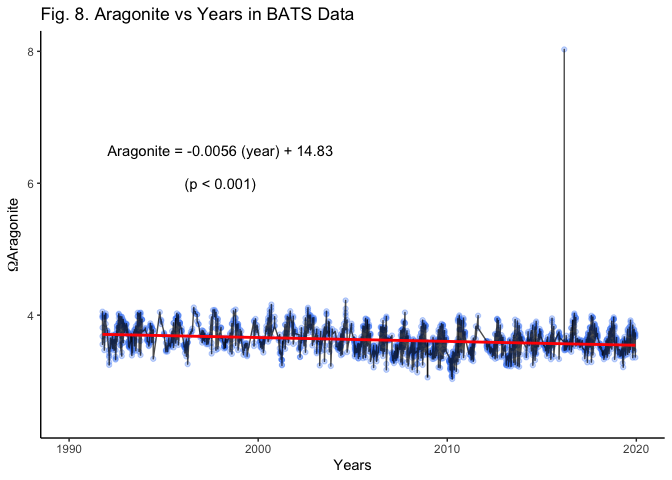

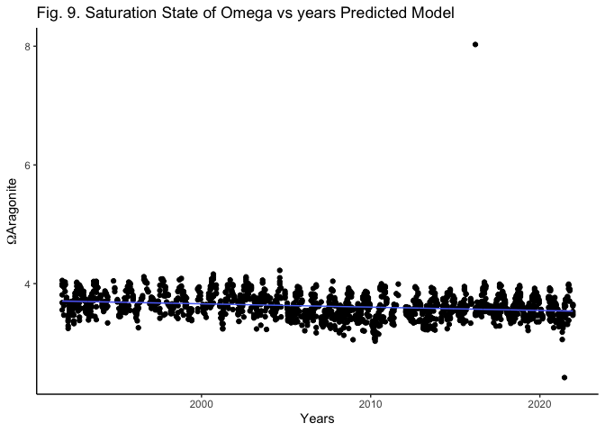

Very similar to pH, the saturation state of Aragonite have a seasonal cycle with high peeks on late winter and lower peeks on early summer. As compared to pH, according to the figure 8, the linear model (red line) shows that there’s a detectable (p<0.001) decrease of Saturation state of Aragonite at a rate of 0.0056±0.00055 per year. This can also be confirmed with figure 9, showing in blue a predicted model in decline. As in the other plots, there is an odd point in the data, this is not deleated until confirmation of BATS that the data is instrument or human error.

# 4. Discussion

The results of this study shows that pCO2 is increasing by 1.8 uatm/year, the pH is decreasing by 0.00176/year and the saturation state of Aragonite is decreasing by 0.0056/year. This is evidence that in the Subtropical North Atlantic, specially in the Bermuda region, there is occurring Ocean Acidification. According to [NOAA](https://www.noaa.gov/news-release/carbon-dioxide-now-more-than-50-higher-than-pre-industrial-levels) measurement of carbon dioxide at the mountaintop observatory on Hawaii’s Big Island had an increase of 1.8ppm over 2021. This results are similar with the pCO2 linear model results of in fact 1.8 uatm/year.

According to the [EEA](https://www.eea.europa.eu/data-and-maps/indicators/ocean-acidification-2/assessment) uzing remote sensing and insitu data, the global average rate of decrease in pH is 0.0017±0.002 pH units/year, this results are also comparable with the result obtain in this study, that showed a pH decrease of 0.00176±0.00000797.

Finally, according to Feely et al, 2011. they observed and average Saturation state of Aragonite decrease of 0.0034 per year. The results in this study shows that the decrease in Ω Aragonite 0.0056/year. Is not as precise as pCO2 and pH result, but comparable. A factor of this small difference is that Feely et al gives a rate of the Pacific Ocean, while our results represent the subtropical Atlantic Ocean.

This results shows that climate change and ocean acidification is real, and need to be study and monitored continuously. CO2 concentration are increasing in the ocean surface, meaning the pH and the Ω Aragonite will continue to decrease. This puts the marine animals in danger. It’s imperative a global change.